# Group Project - Lego Data

# Introduction

The LEGO datasets are a comprehensive collection of information that various aspects of LEGO products. They are made up of 12 interrelated comma-separated variables (csv) files that report on LEGO elements, colors, inventories, minifigures, parts, sets, themes. The question we seek to answer is: **How have the colors of LEGO sets change over time?** Color is a crucial element of LEGO as it contributes to the functionality, aesthetics and distinctiveness of LEGO builds.

# Data Cleaning and Summary

To answer our question, we would need to create a dataframe that consists of LEGO parts, their colour names and RGB codes, as well as years.

### Importing libraries and loading datasets

```r
library(tidyverse)
colors = readr::read_csv('https://raw.githubusercontent.com/rfordatascience/tidytuesday/master/data/2022/2022-09-06/colors.csv.gz')
inventory_parts = readr::read_csv('https://raw.githubusercontent.com/rfordatascience/tidytuesday/master/data/2022/2022-09-06/inventory_parts.csv.gz')
inventories = readr::read_csv('https://raw.githubusercontent.com/rfordatascience/tidytuesday/master/data/2022/2022-09-06/inventories.csv.gz')
sets = readr::read_csv('https://raw.githubusercontent.com/rfordatascience/tidytuesday/master/data/2022/2022-09-06/sets.csv.gz')
inventory_sets = readr::read_csv('https://raw.githubusercontent.com/rfordatascience/tidytuesday/master/data/2022/2022-09-06/inventory_sets.csv.gz')
```

First, we merged the `inventory_parts` and `colours` datasets using a `left_join()`, with the common variable being the parts’ `colour_id`. We then omitted redundant columns and stored this in a variable named `part_colors`. Next, to retrieve the `year` variable, we merged the dataframe `part_colors` with `inventories` using the common variable `inventory_id`, then merged with the `sets` dataframe using the common variable `set_num`. We used `left_join()` for both merges, as the `part_colors` is the main dataframe and stored the resulting dataframe in the variable `part_colors_year`.

### Joining datasets and selecting columns

```r
part_colors = inventory_parts %>%
  left_join(colors, by = c("color_id" = "id")) %>%
  select(-is_spare, -img_url, -is_trans)

part_colors_year = part_colors %>%
  left_join(inventories, by = c("inventory_id" = "id")) %>% #added "version" and "set_num"
  left_join(sets, by = "set_num", suffix = c("_color", "_set")) %>% #added "name_set" "year" "theme_id" "num_parts" "img_url"
  select(-version, -img_url)
head(part_colors_year)
```

```
## # A tibble: 6 × 11
##   inventory_id part_num      color_id quantity name_color rgb   set_num name_set
##          <dbl> <chr>            <dbl>    <dbl> <chr>      <chr> <chr>   <chr>
## 1            1 48379c01            72        1 Dark Blui… 6C6E… 7922-1  McDonal…
## 2            1 48395                7        1 Light Gray 9BA1… 7922-1  McDonal…
## 3            1 stickerupn00…     9999        1 [No Color… 0513… 7922-1  McDonal…
## 4            1 upn0342              0        1 Black      0513… 7922-1  McDonal…
## 5            1 upn0350             25        1 Orange     FE8A… 7922-1  McDonal…
## 6            3 2343                47        1 Trans-Cle… FCFC… 3931-1  Emma's …
## # ℹ 3 more variables: year <dbl>, theme_id <dbl>, num_parts <dbl>
```

Upon analysis of our cleaned dataset, we found that there are 13509 unique sets across 436 distinct themes. There are 204 unique colours, and amidst this, the colour “Black” stands as the colour most frequently used, while “Duplo Medium Green” is the rarest. The LEGO sets span from 1949 to 2022, with the average number of parts hovering around 694. Interestingly, we also found that there are some sets with 0 parts. This suggests anomalies or inaccurate data collection.

### Summary statistics

```r
summary_stats = part_colors_year %>%
  summarise(
    num_uniq_themes = n_distinct(theme_id),
    num_uniq_sets = n_distinct(name_set),
    num_uniq_colors = n_distinct(color_id),
    least_color = names(which.min(table(name_color))),
    most_color = names(which.max(table(name_color))),
    year_range = paste(min(year, na.rm = TRUE), "-", max(year, na.rm = TRUE)),
    min_num_parts = min(num_parts, na.rm = TRUE),
    max_num_parts = max(num_parts, na.rm = TRUE),
    avg_num_parts = mean(num_parts, na.rm = TRUE)
  )
summary_stats
```

```
## # A tibble: 1 × 9
##   num_uniq_themes num_uniq_sets num_uniq_colors least_color        most_color
##             <int>         <int>           <int> <chr>              <chr>
## 1             436         13509             204 Duplo Medium Green Black
## # ℹ 4 more variables: year_range <chr>, min_num_parts <dbl>,
## #   max_num_parts <dbl>, avg_num_parts <dbl>
```

# Visualisations

### Line plot

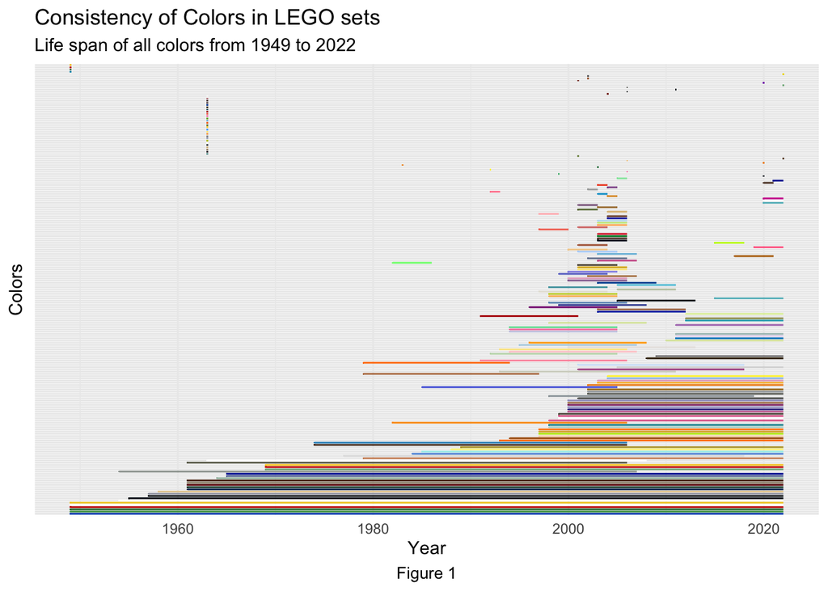

```r
# Find the lifespan of the colors
color_id_year_range = part_colors_year %>%
  filter(!is.na(year)) %>%
  group_by(color_id) %>%
  summarise(year_range = paste(min(year, na.rm = TRUE), "-", max(year, na.rm = TRUE)))

color_id_life_span = color_id_year_range %>%
  separate(year_range, into = c("start_year", "end_year"), convert = TRUE ) %>%
  mutate(lifespan = `end_year` - `start_year` + 1 ) %>%
  arrange(lifespan) %>%
  select(color_id, start_year, end_year, lifespan)

color_theme_life_span = color_id_life_span %>%
  left_join(colors, by = c("color_id"="id")) %>%
  mutate(name = reorder(name, desc(lifespan))) %>%
  mutate(rgb = paste0("#", rgb))

# Plot
ggplot(color_theme_life_span, aes(x = name, y = start_year)) +
  geom_segment(aes(xend = name, y = start_year, yend = end_year, color = I(rgb))) +
  geom_point(shape = ".", aes(color = I(rgb))) +
  coord_flip() +
  labs(title = "Consistency of Colors in LEGO sets",
      subtitle = "Life span of all colors from 1949 to 2022",
       x = "Colors", y = "Year",
      caption = "Figure 1") +
  theme_minimal() +
  theme(axis.text.y = element_blank(),
        axis.ticks.y = element_blank(),
        plot.caption = element_text(hjust = 0.5, size = 10))
```

For this line segment plot, we decided to look at the lifespan of the colors in the lego data set over the years from 1949 to 2022. For each color, we determined the year it was introduced to the end of its existence. From the plot, it is clear that even though the number of colors introduced over time has increased, the lifespan of the colors introduced later became shorter. The first few colors introduced were the basic and primary colors such as Black, White, Red, Yellow, and Blue.

### Bar graph

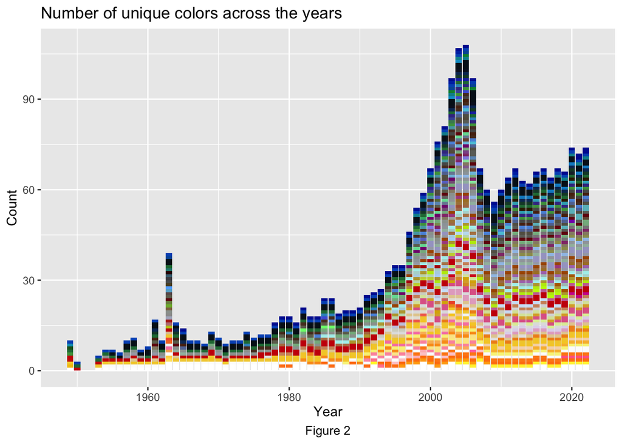

```r
num_unique_year = part_colors_year %>%
  mutate(rgb = paste0("#", rgb)) %>%
  distinct(name_color, rgb, year)

all_rbg = num_unique_year$rgb
names(all_rbg) = all_rbg

num_unique_year %>%
  ggplot(aes(x=year, fill = I(rgb)))+
  geom_bar() +
  labs(title = "Number of unique colors across the years",
       x = "Year", y = "Count",
       caption = "Figure 2") +
  theme(plot.caption = element_text(hjust = 0.5, size = 10))
```

The bar plot shows the number of unique colours in Lego sets in each year, from 1949 to 2022. Each bar is filled with the original Lego bricks’ colours produced, arranged alphabetically using RGB codes from top to bottom. There is an increase in the variety of colours from the beginning to early 2000s, with a sudden spike in 1963 (further explained in the Discussion section). The variety then decreases drastically before increasing gradually again.

### Scatter plot

```r
# find most popular 10 colours from data set
top_10_colors = part_colors_year %>%
  count(name_color, rgb) %>%
  arrange(desc(n)) %>%
  head(10)

top_10_colors_names = top_10_colors %>% pull(name_color)
top_10_colors_rgb = top_10_colors %>% arrange(name_color) %>% pull(rgb)

# df that contains the number of observations, for the above top 10 colours, for each year
data = part_colors_year %>%
  filter(name_color %in% top_10_colors_names) %>%
  count(year, name_color, wt = quantity)
head(data)
```

```
## # A tibble: 6 × 3
##    year name_color     n
##   <dbl> <chr>      <dbl>
## 1  1949 Blue          96
## 2  1949 Red          139
## 3  1949 White        185
## 4  1949 Yellow       106
## 5  1950 Blue          10
## 6  1950 Red            3
```

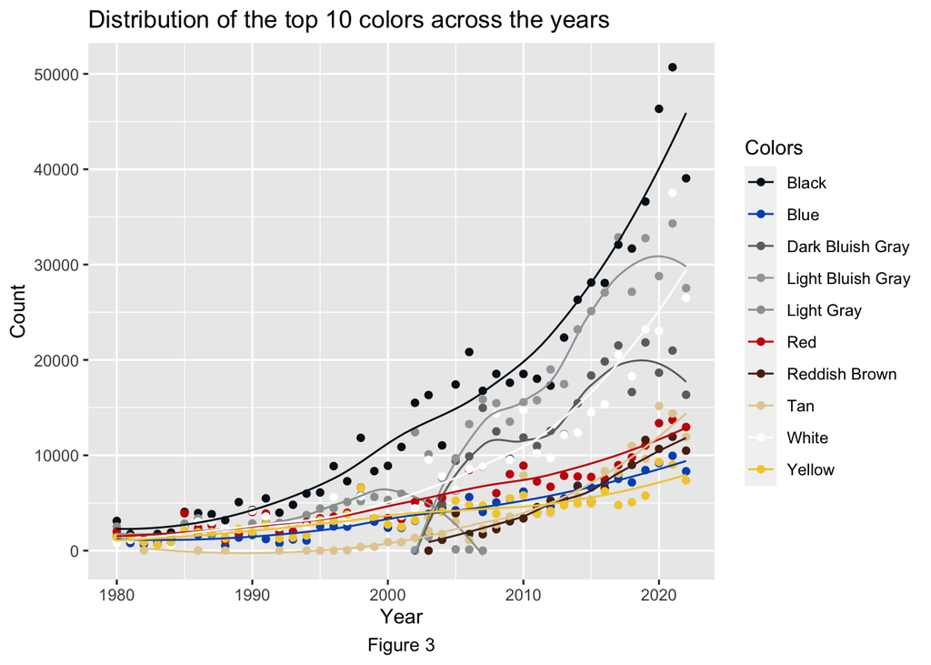

```r
#plotting
ggplot(data = data) +
  geom_point(aes(x = year, y = n, color = name_color)) +
  xlim(1980, 2022) +
  scale_color_manual(values = paste0("#", top_10_colors_rgb)) +
  geom_smooth(aes(x = year, y = n, color = name_color), se = FALSE, size = 0.5) +
  labs(title = "Distribution of the top 10 colors across the years",
       x = "Year", y = "Count",
       color = "Colors",
       caption = "Figure 3") +
  theme(plot.caption = element_text(hjust = 0.5, size = 10))
```

For this scatter plot, our group has decided to focus on years after 1980 only, as the observations of those before 1980 were relatively small and cluttered, making it difficult to establish any meaningful relationships or trends. We chose to focus on the top 10 most popular colors only for the same reasons. This is a plot of count against time, with each data point representing the number of lego pieces of that color for a particular year. We added a LOESS curve for each color as well to make it easier for us to identify the general trends.

# Discussions

There is an overall increasing trend in the number of unique colors over the years from 1949 to 2022. This suggests that LEGO’s color palette continues to evolve over time, producing new and diverse colors for their consumers. We have also noticed that the most popular colors consist of mostly monochromatic shades of black and primary colors, and this is due to their versatility and strong contrast in LEGO builds (Mylenium’s Brick Corner, n.d.).

Upon further inspection, we also recognise a few time periods where there were significant changes in the number of unique colors. The sudden spike in 1963 in Figure 2 was due to the founding of the company, Modulex, under LEGO. Marketed towards architects, the short-lived business created a variety of colors with names starting with “Modulex” (observed correspondingly in the same year in Figure 1). In addition, the increase in the number of unique colors in the 2000s (observed in both Figures 1 and 2) was due to the introduction of commercial themes beginning in the early 2000s (Zapper, n.d.). Both of these observations not only demonstrate the versatility of colors, but also highlights the significance of colors in LEGO.

# References

Georgios Karamanis. (2022). LEGO dataset [Data set]. TidyTuesday. https://github.com/rfordatascience/tidytuesday/tree/master/data/2022/2022-09-06

Mylenium’s Brick Corner. (2022). Yellow Warning – A quick Analysis of LEGO’s new 2022 Color. https://myleniumsbrickcorner.wordpress.com/2022/01/25/yellow-warning-a-quick-analysis-of-legos-new-2022-color/

Zapper. (n.d.) The History of LEGO ® https://www.zapper.co.uk/blog/the-history-of-lego/#:~:text=In%201978%20LEGO%20began%20selling,therefore%20capitalise%20on%20popular%20culture